# Python

Python — скриптовый язык, разработанный Гвидо ван Россумом в качестве простого языка, легкого в изучении новичку. В наше время Python – широко распространенный язык, который используется во многих областях:

- Разработка прикладного ПО (например linux-утилиты yum, pirut, system-config-*, IM-клиент Gajim и многие другие)
- Разработка web-приложений (мощнейший Application-сервер Zope и разработанная на его основе CMS Plone, на основе которой работает например сайт ЦРУ, и масса фреймворков для быстрой разработки приложений Plones, Django, TurboGears и многие другие)
- Использование в качестве встраиваемого скриптового языка во многих играх, и не только (в офисном пакете OpenOffice.org, 3d редакторе Blender, СУБД Postgre)
- Использование в научных расчетах (с пакетами SciPy и numPy для расчетов и PyPlot для рисования графиков Пайтон становится практически сравним с пакетами типа MatLab)

### Python в крупных компаниях

В Amazon и Spotify используют Python для анализа пользовательских данных, информации о продажах и разработки персонализированных рекомендаций.

В Walt Disney применяют этот язык в качестве скриптового для анимации.

YouTube и Instagram… Эти проекты полностью написаны на Python.

Netflix создала свой рекомендательный сервис с нуля на Python.

NASA работает с проектами на этом языке программирования, чтобы проводить научные вычисления.

Dropbox (святая святых Python-программистов. В компании работает и сам создатель языка Гвидо ван Россум);

Google, Netscape, Facebook, Yandex, Microsoft, Intel.

Язык Python – это интерпретируемый язык. Это означает, что помимо непосредственно самой программы, вам необходим специальный инструмент для её запуска. Существуют компилируемые и интерпретируемые языки программирования. В первом случае, программа с языка высокого уровня переводится в машинный код для конкретной платформы. В дальнейшем, среди пользователей, она, как правило, распространяется в виде бинарного файла. Для запуска такой программы не нужны дополнительные программные средства (за исключением необходимых библиотек, но эти тонкости выходят за рамки нашего обсуждения). Самыми распространенными языками такого типа являются C++ и C. Программы на интерпретируемых языках, выполняются интерпретатором и распоространяются в виде исходного кода. На сегодняшний день, среди интерпретируемых языков наиболее популярным является Python.

Один из самых популярных интерпретаторов языка – CPython, написанный на Си. Распространяется эта среда разработки бесплатно по свободной лицензии. Интерпретатор поддерживает большинство популярных платформ.

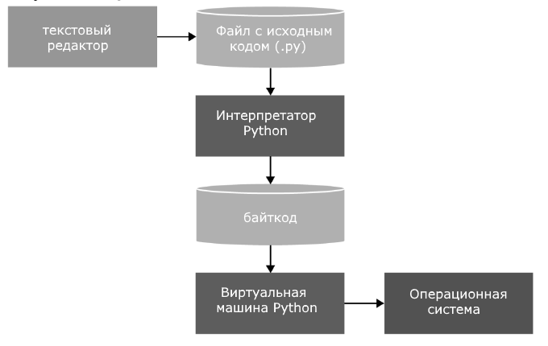

[figure not shown]

### Особенности Python

- Динамическая типизация. В python не надо заранее объявлять тип переменной, что очень удобно при разработке.
- Хорошая поддержка модульности. Вы можете легко написать свой модуль и использовать его в других программах.
- Встроенная поддержка Unicode в строках. В Python необязательно писать всё на английском языке, в программах вполне может использоваться ваш родной язык.
- Поддержка объектно-ориентированного программирования. При этом его реализация в python является одной из самых понятных.
- Автоматическая сборка мусора, отсутствие утечек памяти.
- Интеграция с C/C++, если возможностей python недостаточно.
- Понятный и лаконичный синтаксис, способствующий ясному отображению кода. Удобная система функций позволяет при грамотном подходе создавать код, в котором будет легко разобраться другому человеку в случае необходимости. Также вы сможете научиться читать программы и модули, написанные другими людьми.
- Огромное количество модулей, как входящих в стандартную поставку Python 3, так и сторонних. В некоторых случаях для написания программы достаточно лишь найти подходящие модули и правильно их скомбинировать. Таким образом, вы можете думать о составлении программы на более высоком уровне, работая с уже готовыми элементами, выполняющими различные действия.
- Кроссплатформенность. Программа, написанная на Python, будет функционировать совершенно одинаково вне зависимости от того, в какой операционной системе она запущена. Отличия возникают лишь в редких случаях, и их легко заранее предусмотреть благодаря наличию подробной документации.

### Python 2 vs Python 3

Что такое Python 2? В свое время появление Python 2 значительно упростило процесс разработки кода в сравнении с предыдущими версиями. Теперь были реализованы технические детали Python Enhancement Proposal (PEP).

Python 2.7 (последняя версия в 2.x) больше не разрабатывается. После 2020 года поддержка также прекратилась окончательно.

Что такое Python 3? В декабре 2008 года вышла новая версия Python — 3.0. Версия была выпущена для исправления проблем, присущих Python 2. Важно понимать, что Python 3 несовместим с Python 2. Это обратная несовместимость. Некоторые аспекты Python 3 были перенесены обратно в Python 2.x, чтобы сделать процесс миграции легче в Python 3.

### Синтаксис языка Python

- Конец строки является концом инструкции (точка с запятой не требуется).
- Вложенные инструкции объединяются в блоки по величине отступов. Отступ может быть любым, главное, чтобы в пределах одного вложенного блока отступ был одинаков. И про читаемость кода не забывайте. Отступ в 1 пробел, к примеру, не лучшее решение. Используйте 4 пробела (или знак табуляции, на худой конец).
- Вложенные инструкции в Python записываются в соответствии с одним и тем же шаблоном, когда основная инструкция завершается двоеточием, вслед за которым располагается вложенный блок кода, обычно с отступом под строкой основной инструкции.

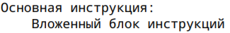

#### Несколько специальных случаев

Но не делайте это слишком часто! Помните об удобочитаемости. А лучше вообще так не делайте.

- Допустимо записывать одну инструкцию в нескольких строках. Достаточно ее заключить в пару круглых, квадратных или фигурных скобок:

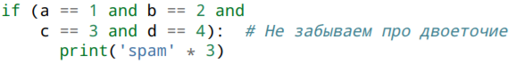

[figure not shown]

```python
print(2 + 3)
print("Hello")
```

```
5
Hello
```

```python
print(2 + 3)
    print("Hello")
```

```
  Input In [2]
    print("Hello")
    ^
IndentationError: unexpected indent
```

```python
if 1 < 2:
    print("Hello")
```

```
Hello
```

### Регистрозависимость

Python - регистрозависимый язык, поэтому выражения print и Print или PRINT представляют разные выражения. И если вместо метода print для вывода на консоль мы попробуем использовать метод Print, то у нас ничего не получится:

```python
Print("Hello World")
```

```
---------------------------------------------------------------------------
NameError                                 Traceback (most recent call last)
Input In [4], in <cell line: 1>()
----> 1 Print("Hello World")

NameError: name 'Print' is not defined
```

### Комментарии

Комментарии в Python бывают блочные и строчные.

Строчные коментарии предваряются знаком решетки - #. Они могут располагаться на отдельной строке:

```python
# Вывод на консоль
# сообщения Hello World
print("Hello World")
```

```python
print("Hello World")  # Вывод сообщения на консоль
```

В блочных коментариях до и после текста комментария ставятся три одинарные кавычки: '''текст комментария'''. Например:

```python
'''
    Вывод на консоль
    сообщения Hello World
'''
print("Hello World")
```

### Вывод на консоль

Основной функцией для вывода информации на консоль является функция print(). В качестве аргумента в эту функцию передается строка, которую мы хотим вывести. Если же нам необходимо вывести несколько значений на консоль, то мы можем передать их в функцию print через запятую:

```python
print(9)
```

```
9
```

```python
print("Full name:", "Tom", "Smith")
print("1455")
```

```
Full name: Tom Smith
1455
```

```python
print(значение, end = конечные_символы)
```

По умолчанию end равен символу "\n", который задает перевод на следующую строку.

```python
print("Hello World", end=" and ")
print("Hello IBA", end=" and ")
print("Hello Python")
```

```
Hello World and Hello IBA and Hello Python
```

### Консольный ввод

```python
name = input("Введите имя: ")
print("Привет", name)
```

```
Введите имя: Hanna
Привет Hanna
```

### Переменные

Переменные предназначены для хранения данных. Название переменной в Python должно начинаться с алфавитного символа или со знака подчеркивания и может содержать алфавитно-цифровые символы и знак подчеркивания. И кроме того, название переменной не должно совпадать с названием ключевых слов языка Python. Ключевых слов не так много, их легко запомнить:

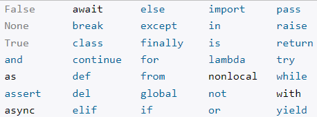

Например, создадим переменную:

```python
name = "Tom"
name
```

```
'Tom'
```

В Python применяется два типа наименования переменных: camel case и underscore notation.

Camel case подразумевает, что каждое новое подслово в наименовании переменной начинается с большой буквы. Например:

```python
userName = "Tom"
```

Underscore notation подразумевает, что подслова в наименовании переменной разделяются знаком подчеркивания. Например:

```python
user_name = "Tom"
```

И также надо учитывать регистрозависимость, поэтому переменные name и Name будут представлять разные объекты.

```python
# две разные переменные
name = "Tom"
Name = "Tom"
```

Определив переменную, мы можем использовать её в программе. Например, попытаться вывести её содержимое с помощью встроенной функции print:

```python
name = "Tom"  # определение переменной name
print(name)   # вывод значения переменной name
```

```
Tom
```

### The Zen of Python

Разработчики языка Python придерживаются определённой философии программирования, называемой «The Zen of Python» («Дзен Питона», или «Дзен Пайтона»). Её текст выдаётся интерпретатором Python по команде import this (работает один раз за сессию).

В целом она подходит к программированию на любом языке.

```python
import this
```

```
The Zen of Python, by Tim Peters

Beautiful is better than ugly.
Explicit is better than implicit.
Simple is better than complex.
Complex is better than complicated.
Flat is better than nested.
Sparse is better than dense.
Readability counts.
Special cases aren't special enough to break the rules.
Although practicality beats purity.
Errors should never pass silently.
Unless explicitly silenced.
In the face of ambiguity, refuse the temptation to guess.
There should be one-- and preferably only one --obvious way to do it.
Although that way may not be obvious at first unless you're Dutch.
Now is better than never.
Although never is often better than *right* now.
If the implementation is hard to explain, it's a bad idea.
If the implementation is easy to explain, it may be a good idea.
Namespaces are one honking great idea -- let's do more of those!
```

### Немного о типизации языков программирования

Если достаточно формально подходить к вопросу о типизации языка Python, то можно сказать, что он относится к языкам с неявной сильной динамической типизацией.

Неявная типизация означает, что при объявлении переменной вам не нужно указывать её тип, при явной – это делать необходимо. В качестве примера языков с явной типизацией можно привести Java, C++. Вот как будет выглядеть объявление целочисленной переменной в Java и Python.

```python
# Java:
int a = 1;

# Python:
a = 1
```

Также языки бывают с динамической и статической типизацией. В первом случае тип переменной определяется непосредственно при выполнении программы, во втором – на этапе компиляции. Как уже было сказано Python – это динамически типизированный язык, такие языки как С, C#, Java – статически типизированные.

Сильная типизация не позволяет производить операции в выражениях с данными различных типов, слабая – позволяет. В языках с сильной типизацией вы не можете складывать, например, строки и числа, нужно все приводить к одному типу. К первой группе можно отнести Python, Java, ко второй – С и С++.

### Типы данных

В Python типы данных можно разделить на встроенные в интерпретатор (built-in) и не встроенные, которые можно использовать при импортировании соответствующих модулей.

К основным встроенным типам относятся:

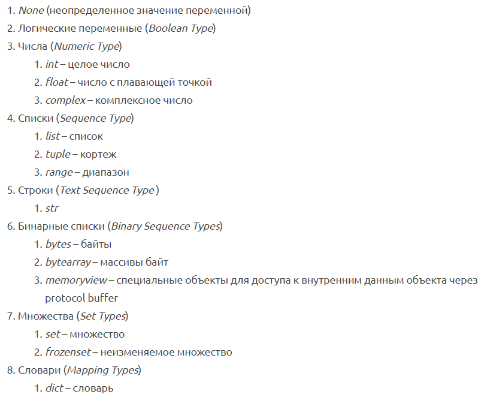

### Модель данных

Для того, чтобы объявить и сразу инициализировать переменную необходимо написать её имя, потом поставить знак равенства и значение, с которым эта переменная будет создана. Например строка: b = 5 объявляет переменную b и присваивает ей значение 5.

Целочисленное значение 5 в рамках языка Python по сути своей является объектом. Объект, в данном случае – это абстракция для представления данных, данные – это числа, списки, строки и т.п. При этом, под данными следует понимать как непосредственно сами объекты, так и отношения между ними (об этом чуть позже). Каждый объект имеет три атрибута – это идентификатор, значение и тип. Идентификатор – это уникальный признак объекта, позволяющий отличать объекты друг от друга, а значение – непосредственно информация, хранящаяся в памяти, которой управляет интерпретатор.

При инициализации переменной, на уровне интерпретатора, происходит следующее:

создается целочисленный объект 5 (можно представить, что в этот момент создается ячейка и 5 кладется в эту ячейку); данный объект имеет некоторый идентификатор, значение: 5, и тип: целое число; посредством оператора “=” создается ссылка между переменной b и целочисленным объектом 5 (переменная b ссылается на объект 5). Имя переменной не должно совпадать с ключевыми словами интерпретатора Python. Его можно получить непосредственно в программе, для этого нужно подключить модуль keyword и воспользоваться командой keyword.kwlist.

```python
b = 5
```

```python
import keyword
print("Python keywords: ", keyword.kwlist)
```

```
Python keywords:  ['False', 'None', 'True', '__peg_parser__', 'and', 'as', 'assert', 'async', 'await', 'break', 'class', 'continue', 'def', 'del', 'elif', 'else', 'except', 'finally', 'for', 'from', 'global', 'if', 'import', 'in', 'is', 'lambda', 'nonlocal', 'not', 'or', 'pass', 'raise', 'return', '…
```

Проверить является или нет идентификатор ключевым словом можно так:

```python
keyword.iskeyword("try")
```

```
True
```

```python
keyword.iskeyword("b")
```

```
False
```

Для того, чтобы посмотреть на объект с каким идентификатором ссылается данная переменная, можно использовать функцию id().

```python
a = 4
b = 5
```

```python
id(a)
```

```
2077895322000
```

```python
id(b)
```

```
2077895322032
```

```python
a = b
id(a)
```

```
2077895322032
```

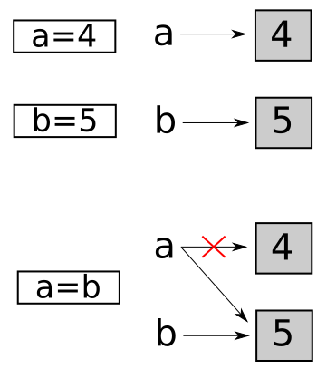

Тип переменной можно определить с помощью функции type(). Пример использования приведен ниже.

```python
a = 10
b = "hello"
c = (1, 2)
type(a)
```

```
int
```

```python
type(b)
```

```
str
```

```python
type(c)
```

```
tuple
```

### Изменяемые и неизменяемые типы данных

В Python существуют изменяемые и неизменяемые типы.

К неизменяемым (immutable) типам относятся: целые числа (int), числа с плавающей точкой (float), комплексные числа (complex), логические переменные (bool), кортежи (tuple), строки (str) и неизменяемые множества (frozen set).

К изменяемым (mutable) типам относятся: списки (list), множества (set), словари (dict).

Как уже было сказано ранее, при создании переменной, вначале создается объект, который имеет уникальный идентификатор, тип и значение, после этого переменная может ссылаться на созданный объект.

Неизменяемость типа данных означает, что созданный объект больше не изменяется. Например, если мы объявим переменную k = 15, то будет создан объект со значением 15, типа int и идентификатором, который можно узнать с помощью функции id().

```python
k = 15
id(k)
```

```
2077895322352
```

```python
type(k)
```

```
int
```

Если тип данных изменяемый, то можно менять значение объекта. Например, создадим список [1, 2], а потом заменим второй элемент на 3.

```python
a = [1, 2]
id(a)
```

```
2078004834432
```

```python
a[1] = 3
a
```

```
[1, 3]
```

```python
id(a)
```

```
2078004834432
```

Как видно, объект на который ссылается переменная a, был изменен. Это можно проиллюстрировать следующим рисунком.

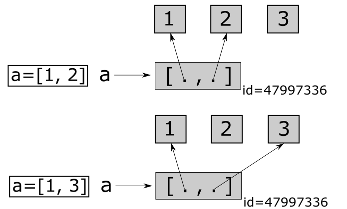

В рассмотренном случае в качестве данных списка выступают не объекты, а отношения между объектами. Т.е. в переменной a хранятся ссылки на объекты, содержащие числа 1 и 3, а не непосредственно сами эти числа.

#### Целые числа (int)

Числа в Python 3 ничем не отличаются от обычных чисел. Они поддерживают набор самых обычных математических операций:

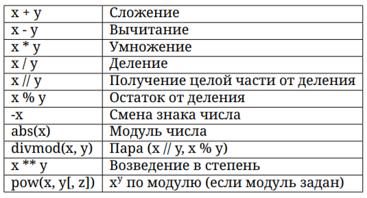

Также нужно отметить, что целые числа в python 3, в отличие от многих других языков, поддерживают длинную арифметику (однако, это требует больше памяти).

```python
20 // 3
```

```
6
```

```python
20 % 3
```

```
2
```

```python
3 ** 4
```

```
81
```

```python
pow(3, 4)
```

```
81
```

```python
pow(3, 4, 27)
```

```
0
```

```python
3 ** 150
```

```
369988485035126972924700782451696644186473100389722973815184405301748249
```

##### Битовые операции

Над целыми числами также можно производить битовые операции

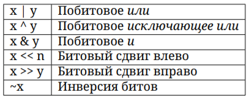

#### Вещественные числа (float)

Вещественные числа поддерживают те же операции, что и целые. Однако (из-за представления чисел в компьютере) вещественные числа неточны, и это может привести к ошибкам:

```python
0.1 + 0.1 + 0.1 + 0.1 + 0.1 + 0.1 + 0.1 + 0.1 + 0.1 + 0.1
```

```
0.9999999999999999
```

Для высокой точности используют другие объекты (например Decimal и Fraction)). Также вещественные числа не поддерживают длинную арифметику:

```python
a = 3 ** 1000
a + 0.1
```

```
---------------------------------------------------------------------------
OverflowError                             Traceback (most recent call last)
Input In [36], in <cell line: 2>()
      1 a = 3 ** 1000
----> 2 a + 0.1

OverflowError: int too large to convert to float
```

Простенькие примеры работы с числами:

```python
c = 150
d = 12.9
c + d
```

```
162.9
```

```python
p = abs(d - c) # Модуль числа
print(p)
```

```
137.1
```

```python
round(p) # Округление
```

```
137
```

Помимо стандартных выражений для работы с числами (а в Python их не так уж и много), в составе Python есть несколько полезных модулей. Модуль math предоставляет более сложные математические функции.

```python
import math
math.pi
```

```
3.141592653589793
```

```python
math.sqrt(85)
```

```
9.219544457292887
```

Модуль random реализует генератор случайных чисел и функции случайного выбора.

```python
import random
random.random()
```

```
0.6125166525545261
```

#### Комплексные числа (complex)

В Python встроены также и комплексные числа:

```python
x = complex(1, 2)
print(x)
```

```
(1+2j)
```

```python
y = complex(3, 4)
print(y)
```

```
(3+4j)
```

```python
z = x + y
print(x)
```

```
(1+2j)
```

```python
print(z)
```

```
(4+6j)
```

```python
z = x * y
print(z)
```

```
(-5+10j)
```

```python
z = x / y
print(z)
```

```
(0.44+0.08j)
```

```python
print(x.conjugate()) # Сопряжённое число
```

```
(1-2j)
```

```python
print(x.imag) # Мнимая часть
```

```
2.0
```

```python
print(x.real) # Действительная часть
```

```
1.0
```

```python
print(x > y) # Комплексные числа нельзя сравнить
```

```
---------------------------------------------------------------------------
TypeError                                 Traceback (most recent call last)
Input In [52], in <cell line: 1>()
----> 1 print(x > y)

TypeError: '>' not supported between instances of 'complex' and 'complex'
```

```python
print(x == y) # Но можно проверить на равенство
```

```
False
```

```python
abs(3 + 4j) # Модуль комплексного числа
```

```
5.0
```

```python
pow(3 + 4j, 2) # Возведение в степень
```

```
(-7+24j)
```

Также для работы с комплексными числами используется модуль cmath.

#### Строки

Строки в Python - упорядоченные последовательности символов, используемые для хранения и представления текстовой информации, поэтому с помощью строк можно работать со всем, что может быть представлено в текстовой форме.

##### Литералы строк

Работа со строками в Python очень удобна. Существует несколько литералов строк, которые мы сейчас и рассмотрим. Строки в апострофах и в кавычках

```python
S = 'spam"s'
S = "spam's"
```

```python
s = 'T'
type(s)
```

```
str
```

```python
s = "Y"
type(s)
```

```
str
```

```python
s = "'Temp'"
print(s)
```

```
'Temp'
```

```python
s = "aaa\v"
print(s)
```

```
aaa
```

Строки в апострофах и в кавычках - одно и то же. Причина наличия двух вариантов в том, чтобы позволить вставлять в литералы строк символы кавычек или апострофов, не используя экранирование.

##### Экранированные последовательности - служебные символы

Экранированные последовательности позволяют вставить символы, которые сложно ввести с клавиатуры.

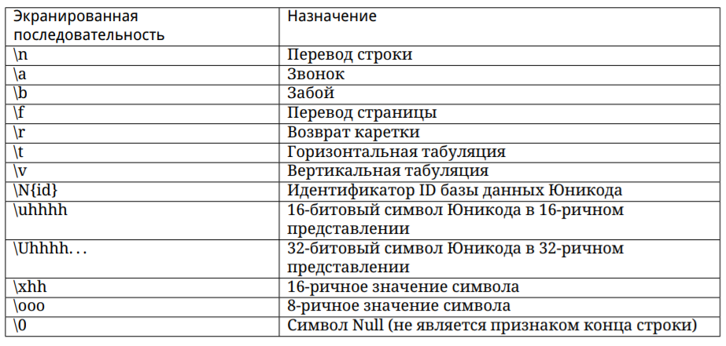

“Сырые” строки - подавляют экранирование Если перед открывающей кавычкой стоит символ ‘r’ (в любом регистре), то механизм экранирования отключается.

```python
S = r'C:\newt.txt'
print(S)
```

```
C:\newt.txt
```

Но, несмотря на назначение, “сырая” строка не может заканчиваться символом обратного слэша. Пути решения:

```python
S = r'\n\n\\'[:-1]
S = r'\n\n' + '\\'
S = '\\n\\n'
```

##### Строки в тройных апострофах или кавычках

Главное достоинство строк в тройных кавычках в том, что их можно использовать для записи многострочных блоков текста. Внутри такой строки возможно присутствие кавычек и апострофов, главное, чтобы не было трех кавычек подряд.

```python
c = '''это очень большая
    строка, многострочный
    блок текста'''
```

```python
c
```

```
'это очень большая\n    строка, многострочный\n    блок текста'
```

```python
print(c)
```

```
это очень большая
    строка, многострочный
    блок текста
```

#### Базовые операции

##### Конкатенация (сложение)

```python
s1 = 'spam'
s2 = 'eggs'
s1 + s2
```

```
'spameggs'
```

##### Дублирование строки

```python
s1 * 3
```

```
'spamspamspam'
```

##### Длина строки (функция len)

```python
len(s1)
```

```
4
```

##### Доступ по индексу

```python
s1[1]
```

```
'p'
```

```python
s1[-2]
```

```
'a'
```

##### Извлечение среза

Оператор извлечения среза: [X:Y]. X – начало среза, а Y – окончание; символ с номером Y в срез не входит. По умолчанию первый индекс равен 0, а второй - длине строки.

```python
s = 'spameggs'
s[3:5]
```

```
'me'
```

```python
s[2:-2]
```

```
'ameg'
```

```python
s[:6]
```

```
'spameg'
```

```python
s[1:]
```

```
'pameggs'
```

```python
s[:]
```

```
'spameggs'
```

Кроме того, можно задать шаг, с которым нужно извлекать срез.

```python
s[::-1]
```

```
'sggemaps'
```

```python
s[3:5:-1]
```

```
''
```

```python
s[2::2]
```

```
'aeg'
```

##### Другие функции и методы строк

При вызове методов необходимо помнить, что строки в Python относятся к категории неизменяемых последовательностей, то есть все функции и методы могут лишь создавать новую строку.

```python
s = 'spam'
```

```python
s[1] = 'b'
```

```
---------------------------------------------------------------------------
TypeError                                 Traceback (most recent call last)
Input In [87], in <cell line: 1>()
----> 1 s[1] = 'b'

TypeError: 'str' object does not support item assignment
```

```python
s = s[0] + 'b' + s[2:]
```

```python
s.upper()
```

```
'SBAM'
```

Поэтому все строковые методы возвращают новую строку, которую потом следует присвоить переменной.

###### Методы для работы со строками

len(S) - Длина строки

S.find(str, [start],[end]) - Поиск подстроки в строке. Возвращает номер первого вхождения или -1:

S.rfind(str, [start],[end]) - Поиск подстроки в строке. Возвращает номер последнего вхождения или -1:

S.index(str, [start],[end]) - Поиск подстроки в строке. Возвращает номер первого вхождения или вызывает ValueError:

S.rindex(str, [start],[end]) - Поиск подстроки в строке. Возвращает номер последнего вхождения или вызывает ValueError:

S.replace(шаблон, замена) - Замена шаблона

S.split(символ) - Разбиение строки по разделителю

S.isdigit() - Состоит ли строка из цифр

S.isalpha() - Состоит ли строка из букв

S.isalnum() - Состоит ли строка из цифр или букв

S.islower() - Состоит ли строка из символов в нижнем регистре

S.isupper() - Состоит ли строка из символов в верхнем регистре

S.isspace() - Состоит ли строка из неотображаемых символов (пробел, символ перевода страницы ('\f'), "новая строка" ('\n'), "перевод каретки" ('\r'), "горизонтальная табуляция" ('\t') и "вертикальная табуляция" ('\v')):

S.istitle() - Начинаются ли слова в строке с заглавной буквы

S.upper() - Преобразование строки к верхнему регистру

S.lower() - Преобразование строки к нижнему регистру

S.startswith(str) - Начинается ли строка S с шаблона str

S.endswith(str) - Заканчивается ли строка S шаблоном str

S.join(список) - Сборка строки из списка с разделителем S

ord(символ) - Символ в его код ASCII

chr(число) - Код ASCII в символ

S.lstrip([chars]) - Удаление пробельных символов в начале строки

S.rstrip([chars]) - Удаление пробельных символов в конце строки

S.strip([chars]) - Удаление пробельных символов в начале и в конце строки

##### Метод format

Иногда (а точнее, довольно часто) возникают ситуации, когда нужно сделать строку, подставив в неё некоторые данные, полученные в процессе выполнения программы (пользовательский ввод, данные из файлов и т. д.). Подстановку данных можно сделать с помощью форматирования строк. Форматирование можно сделать с помощью оператора %, либо с помощью метода format.

Если для подстановки требуется только один аргумент, то значение - сам аргумент:

```python
'Hello, {} !'.format('Vasya')
```

```
'Hello, Vasya !'
```

А если несколько, то значениями будут являться все аргументы со строками подстановки (обычных или именованных):

```python
'{0} , {1} , {2} '.format('a', 'b', 'c')
```

```
'a , b , c '
```

```python
'{} , {} , {} '.format('a', 'b', 'c')
```

```
'a , b , c '
```

```python
'{2} , {1} , {0} '.format('a', 'b', 'c')
```

```
'c , b , a '
```

```python
'{2} , {1} , {0} '.format(*'abc')
```

```
'c , b , a '
```

```python
'{0} {1} {0} '.format('abra', 'cad')
```

```
'abra cad abra '
```

```python
'Coordinates: {latitude} , {longitude} '.format(latitude='37.24N', longitude='-115.81W')
```

```
'Coordinates: 37.24N , -115.81W '
```

```python
coord = {'latitude': '37.24N', 'longitude': '-115.81W'}

'Coordinates: {latitude} , {longitude} '.format(**coord)
```

```
'Coordinates: 37.24N , -115.81W '
```

#### Списки (list)

Списки в Python - упорядоченные изменяемые коллекции объектов произвольных типов (почти как массив, но типы могут отличаться). Чтобы использовать списки, их нужно создать. Создать список можно несколькими способами. Например, можно обработать любой итерируемый объект (например, строку) встроенной функцией list:

```python
list('список')
```

Список можно создать и при помощи литерала:

```python
s = [] # Пустой список
a = list()
```

```python
l = ['s', 'p', ['isok'], 2]
print(l)
```

```
['s', 'p', ['isok'], 2]
```

```python
s
```

```
[]
```

```python
a
```

```
[]
```

```python
l
```

```
['s', 'p', ['isok'], 2]
```

Как и во многих других языках, нумерация элементов начинается с нуля. При попытке доступа к несуществующему индексу возникает исключение IndexError. В данном примере переменная a являлась списком, однако взять элемент по индексу можно и у других типов: строк, кортежей. В Python также поддерживаются отрицательные индексы, при этом нумерация идёт с конца, например:

```python
a = [1, 3, 8, 7]
```

```python
a[-2]
```

```
8
```

```python
a[-5]
```

```
---------------------------------------------------------------------------
IndexError                                Traceback (most recent call last)
Input In [107], in <cell line: 1>()
----> 1 a[-5]

IndexError: list index out of range
```

###### Срезы

В Python, кроме индексов, существуют ещё и срезы. item[START:STOP:STEP] - берёт срез от номера START, до STOP (не включая его), с шагом STEP. По умолчанию START = 0, STOP = длине объекта, STEP = 1. Соответственно, какие-нибудь (а возможно, и все) параметры могут быть опущены.

```python
a = [1, 2, 3, 4, 5, 6, 7, 8]
```

```python
a[::-4]
```

```
[8, 4]
```

```python
a[:100]
```

```
[1, 2, 3, 4, 5, 6, 7, 8]
```

Также с помощью срезов можно не только извлекать элементы, но и добавлять и удалять элементы (разумеется, только для изменяемых последовательностей).

```python
a[1:3] = [0, 0, 0]
```

```python
a
```

```
[1, 0, 0, 0, 4, 5, 6, 7, 8]
```

```python
del a[:-3]
```

```python
a
```

```
[6, 7, 8]
```

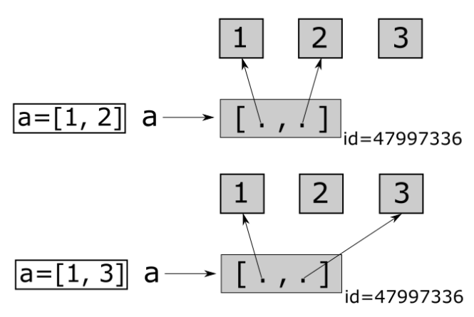

```python
a = [1, 2]
```

```python
id(a)
```

```
2078005378944
```

```python
a[1] = 3
a
```

```
[1, 3]
```

```python
id(a)
```

```
2078005378944
```

```python
b = a.copy()
b
```

[output not shown]

```python
a[1] = 5
```

```python
b
```

[output not shown]

##### Доступ к элементам

###### Добавление элементов

```python
colors = ['Red', 'Blue', 'Green', 'Black', 'White']
```

```python
colors1 = ['Orange', 'Yelloy', 'Blue']
```

```python
#colors1-color2 = [Red', 'Green', 'Black', 'White']
#colors2-color1 = ['Orange', 'Yelloy']

color_1=[]
color_2=[]
for color in colors1:
    if color not in colors2:
        color_1.append(color)
for color in colors2:
    if color not in colors1:
        color_2.append(color)
print(color_1,color_2)
```

[output not shown]

```python
z = list(set(colors).intersection(set(colors1)))
print(z)
```

```
['Blue']
```

```python
new_colors = [x for x in  colors if x[0]=='B']
new_colors
```

```
['Blue', 'Black']
```

```python
colors.append('Orange')
colors
```

```
['Red', 'Blue', 'Green', 'Black', 'White', 'Orange']
```

```python
colors=['Red','Blue','Green','Black','White']
new_mas=[]
for color in colors:
    if color[0]=='B':
        new_mas.append(color)
print(new_mas)
```

```
['Blue', 'Black']
```

```python
colors = ['Red', 'Blue', 'Green', 'Black', 'White']
```

```python
colors.insert(2, 'Purple')
colors
```

[output not shown]

###### Удаление элементов

```python
# Deleting an element by its position
del colors[-1]
```

```python
colors
```

[output not shown]

```python
colors.append("Green")
```

```python
# Removing an item by its value
colors.remove('Green')
```

```python
colors
```

[output not shown]

###### Длина списка

```python
len(colors)
```

```
6
```

###### Цикл

```python
for color in colors:
    print("Welcome, " + color + "!")
```

```
Welcome, Red!
Welcome, Blue!
Welcome, Purple!
Welcome, Black!
Welcome, White!
Welcome, Green!
```

###### Элементарные статистики

```python
nums = [23, 22, 44, 17, 77, 55, 1, 65, 82, 2]
```

```python
sum(nums), min(nums), max(nums)
```

```
(388, 1, 82)
```

##### Генератор списка

```python
squr = []
```

```python
for i in range(1, 10):
    squr.append(i**2)

squr
```

```
[1, 4, 9, 16, 25, 36, 49, 64, 81]
```

```python
# Using a comprehension to generate a list of square numbers
squr = [x**2 for x in range(1, 11)]
squr
```

```
[1, 4, 9, 16, 25, 36, 49, 64, 81, 100]
```

##### Методы для работы со списками

list.append(x) - Добавляет элемент в конец списка

list.extend(L) - Расширяет список list, добавляя в конец все элементы списка L

list.insert(i, x)- Вставляет на i-ый элемент значение x

list.remove(x) - Удаляет первый элемент в списке, имеющий значение x. ValueError, если такого элемента не существует

list.pop([i]) - Удаляет i-ый элемент и возвращает его. Если индекс не указан, удаляется последний элемент

list.index(x, [start [, end]]) - Возвращает положение первого элемента со значением x (при этом поиск ведется от start до end)

list.count(x) - Возвращает количество элементов со значением x

list.sort() - Сортирует список на основе функции

list.reverse() - Разворачивает список

list.copy() - Поверхностная копия списка

list.clear() - Очищает список

Нужно отметить, что методы списков, в отличие от строковых методов, изменяют сам список, а потому результат выполнения не нужно записывать в эту переменную.

```python
t = [4, 455, 16]
```

```python
t.extend(squr)
```

```python
print(t)
```

```
[4, 455, 16, 1, 4, 9, 16, 25, 36, 49, 64, 81, 100]
```

```python
l = [1, 12, 3, -5, 7]
```

```python
l.sort()
```

```python
l
```

```
[-5, 1, 3, 7, 12]
```

#### Кортежи (tuple)

Кортеж, по сути - неизменяемый список. Зачем нужны кортежи, если есть списки?

- Защита от дурака. То есть кортеж защищен от изменений, как намеренных (что плохо), так и случайных (что хорошо).
- Меньший размер.

```python
a = (1, 2, 3, 4, 5, 6)
```

```python
b = [1, 2, 3, 4, 5, 6]
```

```python
a.__sizeof__()
```

```
72
```

```python
b.__sizeof__()
```

```
136
```

- Возможность использовать кортежи в качестве ключей словаря:

```python
d = {(1, 1, 1) : 1}
d
```

```
{(1, 1, 1): 1}
```

```python
d = {[1, 1, 1] : 1}
```

```
---------------------------------------------------------------------------
TypeError                                 Traceback (most recent call last)
Input In [177], in <cell line: 1>()
----> 1 d = {[1, 1, 1] : 1}

TypeError: unhashable type: 'list'
```

Как работать с кортежами?

Создаем пустой кортеж:

```python
a = tuple() # С помощью встроенной функции tuple()
a
```

```
()
```

```python
a = () # С помощью литерала кортежа
a
```

```
()
```

Создаем кортеж из одного элемента:

```python
a = ('s')
a
```

```
's'
```

Стоп. Получилась строка. Но как же так? Мы же кортеж хотели! Как же нам кортеж получить?

```python
a = ('s', )
a
```

```
('s',)
```

Ура! Заработало! Все дело - в запятой. Сами по себе скобки ничего не значат, точнее, значат то, что внутри них находится одна инструкция, которая может быть отделена пробелами, переносом строк и прочим мусором. Кстати, кортеж можно создать и так:

```python
a = 's',
a
```

```
('s',)
```

Но все же не увлекайтесь, и ставьте скобки, тем более, что бывают случаи, когда скобки необходимы. Ну и создать кортеж из итерируемого объекта можно с помощью все той же пресловутой функции tuple()

```python
a = tuple('hello, world!')
a
```

```
('h', 'e', 'l', 'l', 'o', ',', ' ', 'w', 'o', 'r', 'l', 'd', '!')
```

##### Изменение элементов

После создания кортежа элементы изменять нельзя!! Кортежи неизменяемы (unchangeable, or immutable). Но есть обходной путь. Можете преобразовать кортеж в список, изменить список и преобразовать список обратно в кортеж.

```python
x = ("apple", "banana", "cherry")
y = list(x)
y[1] = "kiwi"
x = tuple(y)

x
```

```
('apple', 'kiwi', 'cherry')
```

```python
x = ("apple", "banana", "cherry")
```

```python
x[1]="kiwi"
```

```
---------------------------------------------------------------------------
TypeError                                 Traceback (most recent call last)
Input In [186], in <cell line: 1>()
----> 1 x[1]="kiwi"

TypeError: 'tuple' object does not support item assignment
```

В Pyhon функция zip позволяет пройтись одновременно по нескольким итерируемым объектам. выражение zip(a, b) создает объект-итератор, из которого при каждом обороте цикла извлекается кортеж, состоящий из двух элементов. Первый берется из списка a, второй - из b.

```python
s = 'abc'
t = (10, 20, 30)
f = (3, 5)

a = zip(s,t,f)
list(a)
```

```
[('a', 10, 3), ('b', 20, 5)]
```

##### Операции с кортежами

Все операции над списками, не изменяющие список (сложение, умножение на число, методы index() и count() и некоторые другие операции). Можно также по-разному менять элементы местами и так далее. Например, гордость программистов на python - поменять местами значения двух переменных:

```python
a, b = b, a
```

```python
a = 5
b = 4
a
b
```

```
4
```

```python
a
```

[output not shown]

```python
b
```

[output not shown]

```python
t = (10, 20, 30, 20)
```

```python
t.count(20)
```

```
2
```

```python
t.index(20)
```

```
1
```

count() - Returns the number of times a specified value occurs in a tuple

index() - Searches the tuple for a specified value and returns the position of where it was found

#### Словари (dict)

Словари в Python - неупорядоченные коллекции произвольных объектов с доступом по ключу. Их иногда ещё называют ассоциативными массивами или хеш-таблицами. Чтобы работать со словарём, его нужно создать. Создать его можно несколькими способами. Во-первых, с помощью литерала:

```python
d = {}
d
```

```
{}
```

```python
d = {'dict': 1, 'dictionary': 2}
d
```

```
{'dict': 1, 'dictionary': 2}
```

Во-вторых, с помощью функции dict:

```python
d = dict(short='dict', long='dictionary')
d
```

```
{'short': 'dict', 'long': 'dictionary'}
```

```python
d = dict([(1, 1), (2, 4)])
d
```

```
{1: 1, 2: 4}
```

В-третьих, с помощью метода fromkeys:

```python
d = dict.fromkeys(['a', 'b'])
d
```

```
{'a': None, 'b': None}
```

```python
d = dict.fromkeys(['a', 'b'], 100)
d
```

```
{'a': 100, 'b': 100}
```

В-четвертых, с помощью генераторов словарей, которые очень похожи на генератор списков.

```python
d = {a: a ** 2 for a in range(7)}
d
```

```
{0: 0, 1: 1, 2: 4, 3: 9, 4: 16, 5: 25, 6: 36}
```

Теперь попробуем добавить записи в словарь и извлечь значения ключей:

```python
d = {1: 2, 2: 4, 3: 9}
d[1]
```

```
2
```

```python
d[4] = 4 ** 2
d
```

```
{1: 2, 2: 4, 3: 9, 4: 16}
```

```python
d
```

[output not shown]

```python
d['1']
```

```
---------------------------------------------------------------------------
KeyError                                  Traceback (most recent call last)
Input In [213], in <cell line: 1>()
----> 1 d['1']

KeyError: '1'
```

Как видно из примера, присвоение по новому ключу расширяет словарь, присвоение по существующему ключу перезаписывает его, а попытка извлечения несуществующего ключа порождает исключение. Для избежания исключения есть специальный метод (см. ниже), или можно перехватывать исключение. Что же можно еще делать со словарями? Да то же самое, что и с другими объектами: встроенные функции, ключевые слова (например, циклы for и while), а также специальные методы словарей.

##### Методы словарей

- dict.clear() - очищает словарь.
- dict.copy() - возвращает копию словаря.
- classmethod dict.fromkeys(seq[, value]) - создает словарь с ключами из seq и значением value (по умолчанию None).
- dict.get(key[, default]) - возвращает значение ключа, но если его нет, не бросает исключение, а возвращает default (по умолчанию None).
- dict.items() - возвращает пары (ключ, значение).
- dict.keys() - возвращает ключи в словаре.
- dict.pop(key[, default]) - удаляет ключ и возвращает значение. Если ключа нет, возвращает default (по умолчанию бросает исключение).
- dict.popitem() - удаляет и возвращает пару (ключ, значение). Если словарь пуст, бросает исключение KeyError. Помните, что словари неупорядочены.
- dict.setdefault(key[, default]) - возвращает значение ключа, но если его нет, не бросает исключение, а создает ключ с значением default (по умолчанию None).
- dict.update([other]) - обновляет словарь, добавляя пары (ключ, значение) из other. Существующие ключи перезаписываются. Возвращает None (не новый словарь!).
- dict.values() - возвращает значения в словаре.

```python
# Добавление пары ключ:значение
d.update({7:12})
```

```python
d
```

```
{1: 2, 2: 4, 3: 9, 4: 16, 7: 12}
```

```python
# Удаление элемента
d.pop(2)
d
```

```
{1: 2, 3: 9, 4: 16, 7: 12}
```

```python
del d[3]
```

```python
d
```

```
{1: 2, 4: 16, 7: 12}
```

##### Вложенный словарь

```python
myfamily = {
  "child1" : {
    "name" : "Emil",
    "year" : 2004
  },
  "child2" : {
    "name" : "Tobias",
    "year" : 2007
  },
  "child3" : {
    "name" : "Linus",
    "year" : 2011
  }
}
```

```python
myfamily["child1"]["name"]
```

```
'Emil'
```

```python
for child in myfamily:
    print(child)
    print(myfamily[child]['name'])
```

```
child1
Emil
child2
Tobias
child3
Linus
```

#### Множества (set и frozenset)

Множество в python - “контейнер”, содержащий не повторяющиеся элементы в случайном порядке. Создаём множества:

```python
a = set()
a
```

```
set()
```

```python
a = set('hello')
a
```

```
{'e', 'h', 'l', 'o'}
```

```python
a = {'a', 'b', 'c', 'd'}
a
```

```
{'a', 'b', 'c', 'd'}
```

```python
a = {i ** 2 for i in range(10)} # генератор множеств
a
```

```
{0, 1, 4, 9, 16, 25, 36, 49, 64, 81}
```

```python
type(a)
```

```
set
```

```python
a = {} # А так нельзя!
type(a)
```

```
dict
```

Как видно из примера, множества имеет тот же литерал, что и словарь, но пустое множество с помощью литерала создать нельзя.

Множества удобно использовать для удаления повторяющихся элементов:

```python
words = ['hello', 'daddy', 'hello', 'mum']
set(words)
```

```
{'daddy', 'hello', 'mum'}
```

С множествами можно выполнять множество операций: находить объединение, пересечение и другие

- len(s) - число элементов в множестве (размер множества).
- x in s - принадлежит ли x множеству s.
- set.isdisjoint(other) - истина, если set и other не имеют общих элементов.
- set == other - все элементы set принадлежат other, все элементы other принадлежат set.
- set.issubset(other) или set <= other - все элементы set принадлежат other.
- set.issuperset(other) или set >= other - аналогично.
- set.union(other, ...) или set | other | ... - объединение нескольких множеств.
- set.intersection(other, ...) или set & other & ... - пересечение.
- set.difference(other, ...) или set - other - ... - множество из всех элементов set, не принадлежащие ни одному из other.
- set.symmetric_difference(other); set ^ other - множество из элементов, встречающихся в одном множестве, но не встречающиеся в обоих.
- set.copy() - копия множества.

Операции, непосредственно изменяющие множество:

- set.update(other, ...); set |= other | ... - объединение.
- set.intersection_update(other, ...); set &= other & ... - пересечение.
- set.difference_update(other, ...); set -= other | ... - вычитание.
- set.symmetric_difference_update(other); set ^= other - множество из элементов, встречающихся в одном множестве, но не встречающиеся в обоих.
- set.add(elem) - добавляет элемент в множество.
- set.remove(elem) - удаляет элемент из множества. KeyError, если такого элемента не существует.
- set.discard(elem) - удаляет элемент, если он находится в множестве.
- set.pop() - удаляет первый элемент из множества. Так как множества не упорядочены, нельзя точно сказать, какой элемент будет первым.
- set.clear() - очистка множества.

```python
color_set = set()

color_set.add("Red")
print(color_set)

color_set.update(["Blue", "Green"])
print(color_set)
```

```
{'Red'}
{'Blue', 'Red', 'Green'}
```

```python
color_set.pop()
```

```
'Blue'
```

```python
print(color_set)
```

[output not shown]

```python
color_set.remove('Red')
```

```python
setx
```

[output not shown]

```python
sety
```

[output not shown]

```python
setx = set(["green", "blue"])
sety = set(["blue", "yellow"])
```

```python
# union
setx | sety
```

```
{'blue', 'green', 'yellow'}
```

```python
# intersection
setx & sety
```

```
{'blue'}
```

```python
# difference
setx - sety
```

```
{'green'}
```

```python
# symmetric difference
setx ^ sety
```

```
{'green', 'yellow'}
```

```python
# issubset
# returns True if all items in the set exists in the specified set
setx <= sety
```

```
False
```

###### frozenset

Единственное отличие set от frozenset заключается в том, что set - изменяемый тип данных, а frozenset - нет. Примерно похожая ситуация со списками и кортежами.

```python
a = set('qwerty')
b = frozenset('qwerty')
a == b
```

```
True
```

```python
type(a - b)
```

```
set
```

```python
type(a | b)
```

```
set
```

```python
a.add(1)
```

```python
a
```

```
{1, 'e', 'q', 'r', 't', 'w', 'y'}
```

```python
b.add(1)
```

```
---------------------------------------------------------------------------
AttributeError                            Traceback (most recent call last)
Input In [248], in <cell line: 1>()
----> 1 b.add(1)

AttributeError: 'frozenset' object has no attribute 'add'
```

#### Функции и их аргументы

##### Именные функции, инструкция def

Функция в python - объект, принимающий аргументы и возвращающий значение. Обычно функция определяется с помощью инструкции def. Определим простейшую функцию:

```python
def summa(a, b):
    return a + b

summa(2, 3)
```

```
5
```

Функция может быть любой сложности и возвращать любые объекты (списки, кортежи и даже функции!):

```python
def newfunc(n):
    def myfunc(x):
        return x + n
    return myfunc

new = newfunc(100) # new - это функция
new(200)
```

```
300
```

Функция может и не заканчиваться инструкцией return, при этом функция вернет значение None:

```python
def func():
    pass

print(func())
```

```
None
```

##### Аргументы функции

Функция может принимать произвольное количество аргументов или не принимать их вовсе. Также распространены функции с произвольным числом аргументов, функции с позиционными и именованными аргументами, обязательными и необязательными.

```python
def func(a, b, c=2): # c - необязательный аргумент
    return a + b + c
```

```python
func(1, 2) # a = 1, b = 2, c = 2 (по умолчанию)
```

```
5
```

```python
func(1, 2, 3) # a = 1, b = 2, c = 3
```

```
6
```

```python
func(a=1, b=3) # a = 1, b = 3, c = 2
```

```
6
```

```python
func(a=3, c=6) # a = 3, c = 6, b не определен
```

```
---------------------------------------------------------------------------
TypeError                                 Traceback (most recent call last)
Input In [256], in <cell line: 1>()
----> 1 func(a=3, c=6)

TypeError: func() missing 1 required positional argument: 'b'
```

Функция также может принимать переменное количество позиционных аргументов, тогда перед именем ставится *:

```python
def func(*args):
    return args
```

```python
func(1, 2, 3, 'abc')
```

```
(1, 2, 3, 'abc')
```

```python
func()
```

```
()
```

```python
func(1)
```

```
(1,)
```

Как видно из примера, args - это кортеж из всех переданных аргументов функции, и с переменной можно работать также, как и с кортежем. Функция может принимать и произвольное число именованных аргументов, тогда перед именем ставится **:

```python
def func(**kwargs):
    return kwargs
```

```python
func(a=1, b=2, c=3)
```

```
{'a': 1, 'b': 2, 'c': 3}
```

```python
func()
```

```
{}
```

```python
func(a='python')
```

```
{'a': 'python'}
```

В переменной kwargs у нас хранится словарь, с которым мы, опять-таки, можем делать все, что нам заблагорассудится.

##### Анонимные функции, инструкция lambda

Анонимные функции могут содержать лишь одно выражение, но и выполняются они быстрее. Анонимные функции создаются с помощью инструкции lambda. Кроме этого, их не обязательно присваивать переменной, как мы делали с инструкцией def func():

```python
func = lambda x, y: x + y

func(1, 2)
```

```
3
```

```python
func('a', 'b')
```

```
'ab'
```

```python
(lambda x, y: x + y)(1, 2)
```

```
3
```

```python
(lambda x, y: x + y)('a', 'b')
```

```
'ab'
```

lambda функции, в отличие от обычной, не требуется инструкция return, а в остальном, ведет себя точно так же:

```python
func = lambda *args: args
func(1, 2, 3)
```

```
(1, 2, 3)
```

#### Исключения в python

##### Конструкция try - except для обработки исключений

Исключения (exceptions) - ещё один тип данных в python. Исключения необходимы для того, чтобы сообщать программисту об ошибках. Самый простейший пример исключения - деление на ноль:

```python
100 / 0
```

```
---------------------------------------------------------------------------
ZeroDivisionError                         Traceback (most recent call last)
Input In [272], in <cell line: 1>()
----> 1 100 / 0

ZeroDivisionError: division by zero
```

В данном случае интерпретатор сообщил нам об исключении ZeroDivisionError, то есть делении на ноль. Также возможны и другие исключения:

```python
2 + '1'
```

```
---------------------------------------------------------------------------
TypeError                                 Traceback (most recent call last)
Input In [273], in <cell line: 1>()
----> 1 2 + '1'

TypeError: unsupported operand type(s) for +: 'int' and 'str'
```

```python
int('qwerty')
```

```
---------------------------------------------------------------------------
ValueError                                Traceback (most recent call last)
Input In [274], in <cell line: 1>()
----> 1 int('qwerty')

ValueError: invalid literal for int() with base 10: 'qwerty'
```

В этих двух примерах генерируются исключения TypeError и ValueError соответственно. Подсказки дают нам полную информацию о том, где порождено исключение, и с чем оно связано.

Для обработки исключений используется конструкция try - except. Первый пример применения этой конструкции:

```python
try:
    k = 1 / 0
except ZeroDivisionError:
    k = 0

print(k)
```

```
0
```

В блоке try мы выполняем инструкцию, которая может породить исключение, а в блоке except мы перехватываем их. При этом перехватываются как само исключение, так и его потомки. Например, перехватывая ArithmeticError, мы также перехватываем FloatingPointError, OverflowError и ZeroDivisionError.

```python
try:
    k = 1 / 0
except ArithmeticError:
    k = 0

print(k)
```

```
0
```

Также возможна инструкция except без аргументов, которая перехватывает вообще всё (и прерывание с клавиатуры, и системный выход и т. д.). Поэтому в такой форме инструкция except практически не используется, а используется except Exception. Однако чаще всего перехватывают исключения по одному, для упрощения отладки (вдруг вы ещё другую ошибку сделаете, а except её перехватит). Ещё две инструкции, относящиеся к нашей проблеме, это finally и else. Finally выполняет блок инструкций в любом случае, было ли исключение, или нет (применима, когда нужно непременно что-то сделать, к примеру, закрыть файл). Инструкция else выполняется в том случае, если исключения не было.

```python
print("start")
try:
    val = int(input("input number: "))
    tmp = 10 / val
    print(tmp)
except ValueError as ve:
    print("ValueError! {0}".format(ve))
except ZeroDivisionError as zde:
    print("ZeroDivisionError! {0}".format(zde))
except Exception as ex:
    print("Error! {0}".format(ex))
print("stop")
```

```python
try:
    val = int(input("input number: "))
    tmp = 10 / val
    print(tmp)
except:
    print("Exception")
else:
    print("Final code")
```

```
input number: 13
0.7692307692307693
Final code
```

```python
try:
    raise Exception("Some exception")
except Exception as e:
    print("Exception exception " + str(e))
```

#### == vs is

В Python есть два очень похожих оператора для проверки равенства двух объектов. Эти два оператора is и ==. Их обычно путаются друг с другом, потому что с простыми типами данных, такими как int и string (с которыми многие люди начинают изучать Python), они, кажется, делают то же самое:

```python
x = 5
s = "example"
```

```python
print("x is 5: " + str(x is 5))
```

```
x is 5: True
```

```python
print("x == 5: " + str(x == 5))
```

```
x == 5: True
```

```python
print("s == 'example': " + str(s == "example"))
```

```
s == 'example': True
```

```python
print("s is 'example': " + str(s is "example"))
```

```
s is 'example': True
```

Это показывает, что == и is возвращает одинаковое значение (True) в этих случаях. Однако, если вы попытались сделать это с более сложной структурой:

```python
list = [1]
list
```

```
[1]
```

```python
print("list == [1]: " + str(list == [1]))
```

```
list == [1]: True
```

```python
print("list is [1]: " + str(list is [1]))
```

```
list is [1]: False
```

Здесь становится очевидным, что эти операторы не одинаковы. Разница заключается в том, что is проверяет идентичность (объектов), а == проверяет равенство (значения).

Вот еще один пример, который может прояснить разницу между этими двумя операторами:

```python
list1 = [1]
list2 = [1]
list3 = list1
print("list1 == list2: " + str(list1 == list2))
print("list1 is list2: " + str(list1 is list2))
print("list1 == list3: " + str(list1 == list3))
print("list1 is list3: " + str(list1 is list3))
```

```
list1 == list2: True
list1 is list2: False
list1 == list3: True
list1 is list3: True
```

Как мы видим, list1 по значению равен list2 (они оба равны [1]]), но они не идентичны, то есть они не являются одним и тем же объектом, даже если они имеют одинаковые значения.

Тем не менее, list1 идентичен list3, так как они ссылаются на один и тот же объект в памяти.

#### None (null)

Ключевое слово null обычно используется во многих языках программирования, таких как Java, C++, C# и JavaScript. Это значение, которое присваивается переменной. Концепция ключевого слова null в том, что она дает переменной нейтральное или “нулевое” поведение. А что же в Python?

Эквивалент null в Python: None Он был разработан таким образом, по двум причинам:

- Многие утверждают, что слово null несколько эзотерично. Это не наиболее дружелюбное слово для новичков. Кроме того, None относится именно к требуемой функциональности
- это ничего, и не имеет поведения. Присвоить переменной значение None очень просто:

```python
my_none_variable = None
```

Существует много случаев, когда следует использовать None. Часто вы хотите выполнить действие, которое может работать либо завершиться неудачно. Используя None, вы можете проверить успех действия. Вот пример:

```python
# Мы хотели бы подключиться к базе данных. Мы не знаем, верны ли логин и пароль
# Если соединение с базой будет неуспешно, то он бросит исключение.
# Обратите внимание, что MyDatabase и DatabaseException
# НЕ являются реальными классами, мы просто используем их в качестве примеров.

try:
    database = MyDatabase(db_host, db_user, db_password, db_database)
    database_connection = database.connect()
except DatabaseException:
    pass
if database_connection is None:
    print('The database could not connect')
else:
    print('The database could connect')
```

Python является объектно-ориентированным, и поэтому None - тоже объект, и имеет свой тип.

```python
type(None)
```

### Проверка на null

*Эквивалент null в Python - это None.* Есть (формально) два способа проверить, на равенство None. Один из способов - с помощью ключевого слова is. Второй - с помощью == (но никогда не пользуйтесь вторым способом, и я попробую объяснить, почему). Python предоставляет возможность переопределения операторов сравнения в пользовательских классах. Таким образом, вы можете сравнить классы, например, MyObject == MyOtherObject. Посмотрим на примеры:

```python
class MyClass:
    def __eq__(self, my_object):
        # Просто вернем True
        return True

my_class = MyClass()
```

```python
if my_class is None:
    print('my_class is None, using the is keyword')
else:
    print('my_class is not None, using the is keyword')
```

```
my_class is not None, using the is keyword
```

```python
if my_class == None:
    print('my_class is None, using the == syntax')
else:
    print('my_class is not None, using the == syntax')
```

```
my_class is None, using the == syntax
```

```python
my_class is None
```

И получаем немного неожиданный результат:

my_class is not None, using the is keyword my_class is None, using the == syntax Интересно, не правда ли? Вот поэтому нужно проверять на None с помощью ключевого слова is.

А ещё (для некоторых классов) вызов метода **eq** может занимать много времени, и is будет просто-напросто быстрее.

с boolean типом

```python
0 is False
```

```
False
```

### Циклы

#### if-loop

```python
if выражение:
    инструкция_1
    инструкция_2
    ...
    инструкция_n
```

```python
a = 50

if a < 20:
    print('Hi')
elif a > 30:
    print('Elif')
else:
    print('Bye')
```

```
Elif
```

```python
if a > 20:
    print('Hi')
    if a > 30:
        print('I am here')
```

```
Hi
I am here
```

```python
a + 10 if a > 50 else a / 5
```

```
10.0
```

```python
if not a != 50:
    print(" a!= 50")
```

```
 a!= 50
```

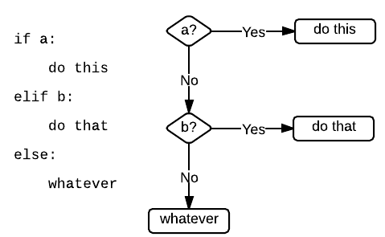

#### Цикл while

While - один из самых универсальных циклов в Python, поэтому довольно медленный. Выполняет тело цикла до тех пор, пока условие цикла истинно.

```python
while (expression) :
    statement_1
    statement_2
    ....
```

```python
i = 5
while i < 15:
    print(i)
    i = i + 2
```

```
5
7
9
11
13
```

#### Цикл for

Цикл for уже чуточку сложнее, чуть менее универсальный, но выполняется гораздо быстрее цикла while. Этот цикл проходится по любому итерируемому объекту (например строке или списку), и во время каждого прохода выполняет тело цикла.

```python
for i in 'hello world':
    print(i * 2, end='')
```

```
hheelllloo  wwoorrlldd
```

Функция range() позволяет вам генерировать ряд чисел в рамках заданного диапазона. В зависимости от того, как много аргументов вы передаете функции, вы можете решить, где этот ряд чисел начнется и закончится, а также насколько велика разница будет между двумя числами.

```python
for i in range(start:stop:step):
    print(i)
```

```python
for i in range(100, 11, -5):
    print(i)
```

```
100
95
90
85
80
75
70
65
60
55
50
45
40
35
30
25
20
15
```

```python
for variable_name in sequence :
    statement_1
    statement_2
    ....
```

```python
for i in range(3):
    print(i)
else:
    print('hi')
```

```
0
1
2
hi
```

#### Оператор continue

Оператор continue начинает следующий проход цикла, минуя оставшееся тело цикла (for или while)

```python
a = 0
while a < 10:
    print(a)
    a += 1
    if a > 6:
        continue
```

```
0
1
2
3
4
5
6
7
8
9
```

#### Оператор break

Оператор break досрочно прерывает цикл

```python
for i in 'hello world':
    if i == 'o':
        break
    print(i * 2, end='')
```

```
hheellll
```

#### Волшебное слово else

Слово else, примененное в цикле for или while, проверяет, был ли произведен выход из цикла инструкцией break, или же “естественным” образом. Блок инструкций внутри else выполнится только в том случае, если выход из цикла произошел без помощи break.

```python
for i in 'hello world':
    if i == 'a':
        break
else:
    print('Буквы a в строке нет')
```

```
Буквы a в строке нет
```

```python
a = 0
while a < 10:
    print(a)
    a += 1
    if a > 6:
        continue
        # break
        # pass
```

### Функция enumerate

Применяется для итерируемых коллекций (строки, списки, словари и др.) и создает объект, который генерирует кортежи, состоящие из двух элементов - индекса элемента и самого элемента.

```python
a = [1, 2, 3]
for i in enumerate(a):
    print(i)
```

```
(0, 1)
(1, 2)
(2, 3)
```

```python
for k, i in enumerate(a):
    print('index: ', k, ' eleem: ', i)
```

```
index:  0  eleem:  1
index:  1  eleem:  2
index:  2  eleem:  3
```

Без использования enumerate в цикл пришлось бы вводить переменную-счетчик или извлекать элементы по индексу

## ДЗ

1 Написать скрипт, который запрашивает ввод фразы и отображает кота, "говорящего" о том, что было предоставлено пользователем. Поместите ввод, предоставленный пользователем, внутри речевого пузыря. Заставьте речевой пузырь расширяться или сжиматься, чтобы он соответствовал вводимым пользователем данным. Пример ввода: "Pet me and I will purr." Пример вывода показан на картинке ниже.

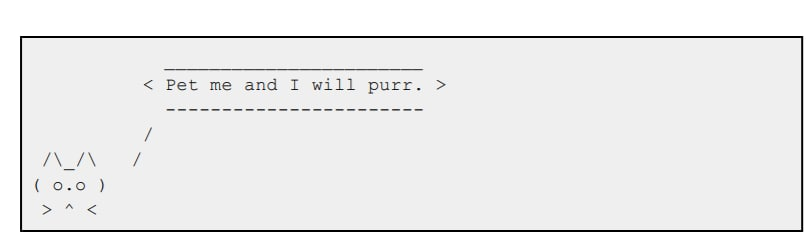

2.1 Составить список покупок. За один раз можно добавить один товар. Количество товаров не ограничено. (Вводить до тех пор, пока не будет введена пустая строка). После завершения ввода всех необходимых покупок, вывести окончательный список.

2.2 Составить список покупок. За один раз можно добавить один товар. Количество товаров не ограничено. (Вводить до тех пор, пока не будет введена пустая строка). После завершения ввода всех необходимых товаров, вывести полученный список продуктов с суммарным количеством каждого товара. Строки должны быть уникальными. Удалить из списка продукт, чаще всего встречающийся в полученном списке.